# EP_W3_1

Name: Syeduzzaman Khan

Project Title: SF Employee Income Analysis

1. Objectives:

   San Francisco is one of the expensive city in the USA. The high salary and house shortage have increased the city dwellers living cost. Recently, the sharp raises of salary has added extra fuel to ramp the cost of living. The San Francisco Controller's Office keeps records the salary information from 2013 to present.

   The goal of this project is to get an insight of the SF employee compensation and analyze so that San Francisco Chronicle newspaper can be published as the main page article next month.

   To achieve the San Francisco Chronicle newspaper goal, we have to carefully analyze the dataset considering different perspectives. At the beginning of the project, we will get too familiar with the dataset and look into different columns. Then, we will pick the relevant columns that will lead us to reach our goals. The obtained results will be visualized using plot and table.

# 2. Data Exploration:

Read dataset

```r
# read csv file

dataset <- read.csv ("employee-compensation.csv", na.strings="",stringsAsFactors=FALSE)
```

```r
cat("Display top 10 rows:") # print message
head (dataset,n=20) # print top 10 rows
cat("\n \n")
cat ("Number of Rows: ",nrow(dataset)) # calculate number of rows
cat ("\nNumber of Columns: ",ncol(dataset)) # calculate number of coloumns
cat ("\nTypes of Columns:") # columns types i.e. int,chr,num etc.

str(dataset)

# Percentiles of the numerical values
Salaries<-as.numeric(dataset$Salaries)
cat("\nPercentiles of Salaries [USD]: \n")
quantile(Salaries, prob = c(0.25, 0.50, 0.75,1)) # percentiles of Salaries
cat("\nMedian of Salaries [USD]: \n")
median(Salaries)


Overtime<-as.numeric(dataset$Overtime)
cat("\nPercentiles of Overtime [USD]: \n")
quantile(Overtime, prob = c(0.25, 0.50, 0.75,1)) # percentiles of Overtime
cat("\nMedian of Overtime [USD]: \n")
median(Overtime)

Other.Salaries<-as.numeric(dataset$Other.Salaries)
cat("\nPercentiles of Other Salaries [USD]: \n")
quantile(Overtime, prob = c(0.25, 0.50, 0.75,1)) # percentiles of Other Salaries
cat("\nMedian of Other Salaries [USD]: \n")
median(Other.Salaries)

total_salary<-as.numeric(dataset$Total.Salary)
cat("\nPercentiles of Total Salary [USD]: \n")
quantile(total_salary, prob = c(0.25, 0.50, 0.75,1)) # percentiles of Total Salary
cat("\nMedian of Total Salaries [USD]: \n")
median(total_salary)# median of Total Salary

Retirement<-as.numeric(dataset$Retirement)
cat("\nPercentiles of Retirement [USD]: \n")
quantile(Retirement, prob = c(0.25, 0.50, 0.75,1)) # percentiles of Retirement
cat("\nMedian of Retirement [USD]: \n")
median(Retirement)# median of Retirement

Health.Dental<-as.numeric(dataset$Health.Dental)
cat("\nPercentiles of Health Dental [USD]: \n")
quantile(Health.Dental, prob = c(0.25, 0.50, 0.75,1)) # percentiles of Health Dental
cat("\nMedian of Health Dental [USD]: \n")
median(Health.Dental)# median of Health Dental

Other.Benefits<-as.numeric(dataset$Other.Benefits)
cat("\nPercentiles of Other Benefits [USD]: \n")
quantile(Other.Benefits, prob = c(0.25, 0.50, 0.75,1)) # percentiles of Other Benefits
cat("\nMedian of Other Benefits [USD]: \n")
median(Other.Benefits)# median of Other Benefits


total_Benefits<-as.numeric(dataset$Total.Benefits)
cat("\nPercentiles of Total Benefits [USD]: \n")
quantile(total_Benefits, prob = c(0.25, 0.50, 0.75,1)) # percentiles of Total Benefits
cat("\nMedian of total Benefits [USD]: \n")
median(total_Benefits)# median of total Benefits

total_Compensation<-as.numeric(dataset$Total.Compensation)
cat("\nPercentiles of Total Compensation [USD]: \n")
quantile(total_Compensation, prob = c(0.25, 0.50, 0.75,1)) # percentiles of Total Compensation
cat("\nMedian of total Compensation [USD]: \n")
median(total_Compensation)# median of total Compensation

# count function
```

```
Display top 10 rows:
```

| Year.Type | Year | Organization.Group.Code | Organization.Group | Department.Code | Department | Union.Code | Union | Job.Family.Code | Job.Family | ⋯ | Employee.Identifier | Salaries | Overtime | Other.Salaries | Total.Salary | Retirement | Health.Dental | Other.Benefits | Total.Benefits | Total.Compensation |
| --- | --- | --- | --- | --- | --- | --- | --- | --- | --- | --- | --- | --- | --- | --- | --- | --- | --- | --- | --- | --- |
| Fiscal | 2013 | 1 | Public Protection | FIR | FIR Fire Department | 798 | Firefighters - Miscellaneous, Local 798 | H000 | Fire Services | ⋯ | 37216 | 123841.28 | 76853.77 | 14922.05 | 215617.10 | 24574.98 | 14920.13 | 3589.87 | 43084.98 | 258702.08 |
| Fiscal | 2014 | 2 | Public Works, Transportation & Commerce | MTA | MTA Municipal Transprtn Agncy | 261 | Laborers, Local 261 | 7500 | Semi-Skilled & General Labor | ⋯ | 24950 | 61137.60 | 7341.04 | 9218.74 | 77697.38 | 14897.71 | 12516.70 | 6117.99 | 33532.40 | 111229.78 |
| Fiscal | 2016 | 2 | Public Works, Transportation & Commerce | AIR | AIR Airport Commission | 790 | SEIU - Miscellaneous, Local 1021 | 1400 | Clerical, Secretarial & Steno | ⋯ | 27447 | 41192.82 | 0.00 | 390.00 | 41582.82 | 6996.41 | 11308.96 | 3200.69 | 21506.06 | 63088.88 |
| Fiscal | 2015 | 2 | Public Works, Transportation & Commerce | MTA | MTA Municipal Transprtn Agncy | 253 | Transport Workers - Transit Operators, Local 250-A | 9100 | Street Transit | ⋯ | 42001 | 66993.68 | 26633.83 | 4494.98 | 98122.49 | 21231.91 | 13417.45 | 7449.63 | 42098.99 | 140221.48 |
| Fiscal | 2013 | 2 | Public Works, Transportation & Commerce | DPW | DPW GSA - Public Works | 21 | Prof & Tech Engineers - Miscellaneous, Local 21 | 5200 | Professional Engineering | ⋯ | 22142 | 74260.80 | 0.00 | 0.00 | 74260.80 | 13522.95 | 11989.39 | 5977.19 | 31489.53 | 105750.33 |
| Fiscal | 2015 | 2 | Public Works, Transportation & Commerce | MTA | MTA Municipal Transprtn Agncy | 21 | Prof & Tech Engineers - Miscellaneous, Local 21 | 5200 | Professional Engineering | ⋯ | 56724 | 141778.27 | 0.00 | 0.00 | 141778.27 | 31106.23 | 11435.72 | 9499.81 | 52041.76 | 193820.03 |
| Fiscal | 2015 | 2 | Public Works, Transportation & Commerce | MTA | MTA Municipal Transprtn Agncy | 790 | SEIU - Miscellaneous, Local 1021 | 1900 | Purchasing & Storekeeping | ⋯ | 40114 | 51152.50 | 25724.87 | 4312.70 | 81190.07 | 13299.95 | 11782.99 | 6492.68 | 31575.62 | 112765.69 |
| Fiscal | 2015 | 1 | Public Protection | DAT | DAT District Attorney | 790 | SEIU - Miscellaneous, Local 1021 | 8100 | Legal & Court | ⋯ | 50362 | 27351.96 | 0.00 | 0.00 | 27351.96 | 6135.08 | 5786.71 | 2090.58 | 14012.37 | 41364.33 |
| Fiscal | 2013 | 3 | Human Welfare & Neighborhood Development | DSS | HSA Human Services Agency | 535 | SEIU - Human Services, Local 1021 | 2900 | Human Services | ⋯ | 34064 | 72115.16 | 0.00 | 2122.80 | 74237.96 | 13518.68 | 12803.48 | 6202.78 | 32524.94 | 106762.90 |
| Fiscal | 2015 | 6 | General Administration & Finance | REG | REG Elections | 790 | SEIU - Miscellaneous, Local 1021 | 1400 | Clerical, Secretarial & Steno | ⋯ | 49417 | 391.25 | 322.78 | 0.00 | 714.03 | 0.00 | 119.75 | 55.28 | 175.03 | 889.06 |
| Fiscal | 2013 | 2 | Public Works, Transportation & Commerce | MTA | MTA Municipal Transprtn Agncy | 21 | Prof & Tech Engineers - Miscellaneous, Local 21 | 5300 | Sub-Professional Engineering | ⋯ | 31980 | 90220.00 | 8067.76 | 0.00 | 98287.76 | 16429.13 | 12828.16 | 7714.64 | 36971.93 | 135259.69 |
| Fiscal | 2013 | 4 | Community Health | DPH | DPH Public Health | 250 | SEIU - Health Workers, Local 1021 | 2500 | Med Therapy & Auxiliary | ⋯ | 54470 | 38041.00 | 5442.31 | 2150.29 | 45633.60 | 7878.23 | 12334.77 | 3692.35 | 23905.35 | 69538.95 |
| Fiscal | 2015 | 6 | General Administration & Finance | MYR | MYR Mayor | 21 | Prof & Tech Engineers - Miscellaneous, Local 21 | 1600 | Payroll, Billing & Accounting | ⋯ | 17035 | 97120.60 | 0.00 | 0.00 | 97120.60 | 21784.05 | 12501.58 | 7985.67 | 42271.30 | 139391.90 |
| Fiscal | 2014 | 4 | Community Health | DPH | DPH Public Health | 790 | SEIU - Miscellaneous, Local 1021 | 9900 | Public Service Aide | ⋯ | 15032 | 19205.10 | 0.00 | 0.00 | 19205.10 | 184.90 | 6605.57 | 1450.92 | 8241.39 | 27446.49 |
| Fiscal | 2013 | 4 | Community Health | DPH | DPH Public Health | 791 | SEIU - Staff and Per Diem Nurses, Local 1021 | 2300 | Nursing | ⋯ | 52991 | 11711.79 | 0.00 | 107.15 | 11818.94 | 3399.43 | 0.00 | 5228.17 | 8627.60 | 20446.54 |
| Fiscal | 2013 | 3 | Human Welfare & Neighborhood Development | CHF | CHF Children;Youth & Families | 790 | SEIU - Miscellaneous, Local 1021 | 9700 | Community Development | ⋯ | 26061 | 61996.26 | 0.00 | 0.00 | 61996.26 | 10979.60 | 8881.03 | 5217.16 | 25077.79 | 87074.05 |
| Fiscal | 2015 | 6 | General Administration & Finance | TIS | DT GSA - Technology | 6 | Electrical Workers, Local 6 | 7300 | Journeyman Trade | ⋯ | 4342 | 63502.79 | 19756.54 | 1229.40 | 84488.73 | 14398.42 | 8456.15 | 6694.69 | 29549.26 | 114037.99 |
| Fiscal | 2014 | 5 | Culture & Recreation | LIB | LIB Public Library | 790 | SEIU - Miscellaneous, Local 1021 | 3600 | Library | ⋯ | 48103 | 29281.58 | 0.00 | 0.00 | 29281.58 | 6242.84 | 6234.38 | 2411.15 | 14888.37 | 44169.95 |
| Fiscal | 2015 | 1 | Public Protection | POL | POL Police | 911 | Police Officers' Association | Q000 | Police Services | ⋯ | 19413 | 1078.50 | 323.55 | 28.11 | 1430.16 | 233.14 | 119.75 | 24.32 | 377.21 | 1807.37 |
| Fiscal | 2017 | 4 | Community Health | DPH | DPH Public Health | 790 | SEIU - Miscellaneous, Local 1021 | 1400 | Clerical, Secretarial & Steno | ⋯ | 8954 | 59080.32 | 0.00 | 1080.00 | 60160.32 | 12417.05 | 13765.55 | 4662.51 | 30845.11 | 91005.43 |

```
Number of Rows:  213202
Number of Columns:  22
Types of Columns:'data.frame':	213202 obs. of  22 variables:
 $ Year.Type              : chr  "Fiscal" "Fiscal" "Fiscal" "Fiscal" ...
 $ Year                   : int  2013 2014 2016 2015 2013 2015 2015 2015 2013 2015 ...
 $ Organization.Group.Code: int  1 2 2 2 2 2 2 1 3 6 ...
 $ Organization.Group     : chr  "Public Protection" "Public Works, Transportation & Commerce" "Public Works, Transportation & Commerce" "Public Works, Transportation & Commerce" ...
 $ Department.Code        : chr  "FIR" "MTA" "AIR" "MTA" ...
 $ Department             : chr  "FIR Fire Department" "MTA Municipal Transprtn Agncy" "AIR Airport Commission" "MTA Municipal Transprtn Agncy" ...
 $ Union.Code             : int  798 261 790 253 21 21 790 790 535 790 ...
 $ Union                  : chr  "Firefighters - Miscellaneous, Local 798" "Laborers, Local 261" "SEIU - Miscellaneous, Local 1021" "Transport Workers - Transit Operators, Local 250-A" ...
 $ Job.Family.Code        : chr  "H000" "7500" "1400" "9100" ...
 $ Job.Family             : chr  "Fire Services" "Semi-Skilled & General Labor" "Clerical, Secretarial & Steno" "Street Transit" ...
 $ Job.Code               : chr  "H003" "7514" "1406" "9163" ...
 $ Job                    : chr  "EMT/Paramedic/Firefighter" "General Laborer" "Senior Clerk" "Transit Operator" ...
 $ Employee.Identifier    : int  37216 24950 27447 42001 22142 56724 40114 50362 34064 49417 ...
 $ Salaries               : num  123841 61138 41193 66994 74261 ...
 $ Overtime               : num  76854 7341 0 26634 0 ...
 $ Other.Salaries         : num  14922 9219 390 4495 0 ...
 $ Total.Salary           : num  215617 77697 41583 98122 74261 ...
 $ Retirement             : num  24575 14898 6996 21232 13523 ...
 $ Health.Dental          : num  14920 12517 11309 13417 11989 ...
 $ Other.Benefits         : num  3590 6118 3201 7450 5977 ...
 $ Total.Benefits         : num  43085 33532 21506 42099 31490 ...
 $ Total.Compensation     : num  258702 111230 63089 140221 105750 ...

Percentiles of Salaries [USD]:
```

**25%**

23165.535

**50%**

63210.84

**75%**

93215.01

**100%**

533985.94

```
Median of Salaries [USD]:
```

63210.84

```
Percentiles of Overtime [USD]:
```

**25%**

0

**50%**

0

**75%**

2872.0125

**100%**

227313.62

```
Median of Overtime [USD]:
```

0

[output not shown]

**25%**

0

**50%**

0

**75%**

2872.0125

**100%**

227313.62

```
Median of Other Salaries [USD]:
```

690.715

```
Percentiles of Total Salary [USD]:
```

**25%**

25100.6875

**50%**

68641.71

**75%**

104364.9575

**100%**

533985.94

```
Median of Total Salaries [USD]:
```

68641.71

```
Percentiles of Retirement [USD]:
```

**25%**

3204.38

**50%**

12837.99

**75%**

19117.24

**100%**

101306.01

```
Median of Retirement [USD]:
```

12837.99

```
Percentiles of Health Dental [USD]:
```

**25%**

4272.07

**50%**

12132.89

**75%**

12828.7075

**100%**

22270.12

```
Median of Health Dental [USD]:
```

12132.89

```
Percentiles of Other Benefits [USD]:
```

**25%**

1578.1325

**50%**

4395.385

**75%**

6950.2275

**100%**

36815.39

```
Median of Other Benefits [USD]:
```

4395.385

```
Percentiles of Total Benefits [USD]:
```

**25%**

9302.3525

**50%**

30311.045

**75%**

38497.8875

**100%**

138503.52

```
Median of total Benefits [USD]:
```

30311.045

```
Percentiles of Total Compensation [USD]:
```

**25%**

35380.3375

**50%**

98783.275

**75%**

143207.46

**100%**

668412.41

```
Median of total Compensation [USD]:
```

98783.275

# 3. Subsets of Data:

```r
# 1. Professional Engineering salary dataset 2013 to 2017
    P_E_salary_2013<-dataset[dataset$Job.Family=="Professional Engineering" & dataset$Year=="2013",c("Year", "Total.Salary","Total.Compensation")]
    P_E_salary_2014<-dataset[dataset$Job.Family=="Professional Engineering" & dataset$Year=="2014",c("Year", "Total.Salary","Total.Compensation")]
    P_E_salary_2015<-dataset[dataset$Job.Family=="Professional Engineering" & dataset$Year=="2015",c("Year", "Total.Salary","Total.Compensation")]
    P_E_salary_2016<-dataset[dataset$Job.Family=="Professional Engineering" & dataset$Year=="2016",c("Year", "Total.Salary","Total.Compensation")]
    P_E_salary_2017<-dataset[dataset$Job.Family=="Professional Engineering" & dataset$Year=="2017",c("Year", "Total.Salary","Total.Compensation")]
    cat("Professional Engineer:\n")
    head(P_E_salary_2017,n=2)

# 2. Fire service salary dataset 2013 to 2017
    F_S_salary_2013<-dataset[dataset$Job.Family=="Fire Services" & dataset$Year=="2013",c("Year", "Total.Salary","Total.Compensation")]
    F_S_salary_2014<-dataset[dataset$Job.Family=="Fire Services" & dataset$Year=="2014",c("Year", "Total.Salary","Total.Compensation")]
    F_S_salary_2015<-dataset[dataset$Job.Family=="Fire Services" & dataset$Year=="2015",c("Year", "Total.Salary","Total.Compensation")]
    F_S_salary_2016<-dataset[dataset$Job.Family=="Fire Services" & dataset$Year=="2016",c("Year", "Total.Salary","Total.Compensation")]
    F_S_salary_2017<-dataset[dataset$Job.Family=="Fire Services" & dataset$Year=="2017",c("Year", "Total.Salary","Total.Compensation")]
    cat("\nFire service:\n")

    head(F_S_salary_2017,n=2)

# 3. Semi-Skilled & General Labor salary dataset 2013 to 2017

    S_S_salary_2013<-dataset[dataset$Job.Family=="Semi-Skilled & General Labor" & dataset$Year=="2013",c("Year", "Total.Salary","Total.Compensation")]
    S_S_salary_2014<-dataset[dataset$Job.Family=="Semi-Skilled & General Labor" & dataset$Year=="2014",c("Year", "Total.Salary","Total.Compensation")]
    S_S_salary_2015<-dataset[dataset$Job.Family=="Semi-Skilled & General Labor" & dataset$Year=="2015",c("Year", "Total.Salary","Total.Compensation")]
    S_S_salary_2016<-dataset[dataset$Job.Family=="Semi-Skilled & General Labor" & dataset$Year=="2016",c("Year", "Total.Salary","Total.Compensation")]
    S_S_salary_2017<-dataset[dataset$Job.Family=="Semi-Skilled & General Labor" & dataset$Year=="2017",c("Year", "Total.Salary","Total.Compensation")]
    cat("\nSemi-Skilled & General Labor:\n")

    head(S_S_salary_2017,n=2)
# 4. Agriculture & Horticulture salary dataset 2013 to 2017
    Agriculture_salary_2013<-dataset[dataset$Job.Family=="Agriculture & Horticulture" & dataset$Year=="2013",c("Year", "Total.Salary","Total.Compensation")]
    Agriculture_salary_2014<-dataset[dataset$Job.Family=="Agriculture & Horticulture" & dataset$Year=="2014",c("Year", "Total.Salary","Total.Compensation")]
    Agriculture_salary_2015<-dataset[dataset$Job.Family=="Agriculture & Horticulture" & dataset$Year=="2015",c("Year", "Total.Salary","Total.Compensation")]
    Agriculture_salary_2016<-dataset[dataset$Job.Family=="Agriculture & Horticulture" & dataset$Year=="2016",c("Year", "Total.Salary","Total.Compensation")]
    Agriculture_salary_2017<-dataset[dataset$Job.Family=="Agriculture & Horticulture" & dataset$Year=="2017",c("Year", "Total.Salary","Total.Compensation")]
    cat("\nAgriculture & Horticulture:\n")

    head(Agriculture_salary_2017,n=2)

# 5. Nursing salary dataset 2013 to 2017
    Nursing_salary_2013<-dataset[dataset$Job.Family=="Nursing" & dataset$Year=="2013",c("Year", "Total.Salary","Total.Compensation")]
    Nursing_salary_2014<-dataset[dataset$Job.Family=="Nursing" & dataset$Year=="2014",c("Year", "Total.Salary","Total.Compensation")]
    Nursing_salary_2015<-dataset[dataset$Job.Family=="Nursing" & dataset$Year=="2015",c("Year", "Total.Salary","Total.Compensation")]
    Nursing_salary_2016<-dataset[dataset$Job.Family=="Nursing" & dataset$Year=="2016",c("Year", "Total.Salary","Total.Compensation")]
    Nursing_salary_2017<-dataset[dataset$Job.Family=="Nursing" & dataset$Year=="2017",c("Year", "Total.Salary","Total.Compensation")]
    cat("\nNursing salary:\n")

    head(Nursing_salary_2017,n=2)
```

```
Professional Engineer:
```

|  | Year | Total.Salary | Total.Compensation |
| --- | --- | --- | --- |
| 174 | 2017 | 101415.73 | 141071.9 |
| 319 | 2017 | 94638.65 | 133369.4 |

```
Fire service:
```

|  | Year | Total.Salary | Total.Compensation |
| --- | --- | --- | --- |
| 97 | 2017 | 149841.8 | 192393.1 |
| 178 | 2017 | 133815.6 | 174996.7 |

```
Semi-Skilled & General Labor:
```

|  | Year | Total.Salary | Total.Compensation |
| --- | --- | --- | --- |
| 393 | 2017 | 4839.36 | 7288.41 |
| 520 | 2017 | 72457.90 | 104550.73 |

```
Agriculture & Horticulture:
```

|  | Year | Total.Salary | Total.Compensation |
| --- | --- | --- | --- |
| 311 | 2017 | 72762.08 | 105511.1 |
| 1144 | 2017 | 85535.24 | 121911.0 |

```
Nursing salary:
```

|  | Year | Total.Salary | Total.Compensation |
| --- | --- | --- | --- |
| 70 | 2017 | 110311.4 | 147585.5 |
| 141 | 2017 | 111383.2 | 146749.1 |

# 3.1 Subsets of Data: Explanation

The subsets of data set are categorized the employees based on skilled, semi-skilled, and non-skilled. Also, each subset includes total salary and total compensation information in the year of 2017.

# 4. Plots:

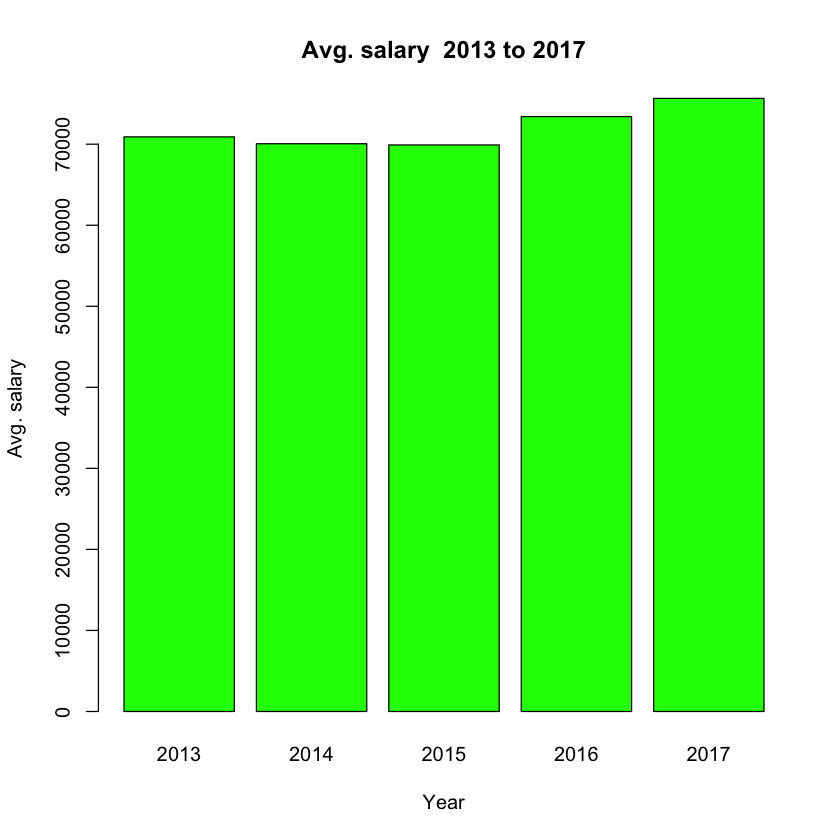

```r
#1. Avg salary plot for 2013 to 2017
salary_2013<-mean(dataset[dataset$Year=="2013",c("Total.Salary")])
salary_2014<-mean(dataset[dataset$Year=="2014",c("Total.Salary")])
salary_2015<-mean(dataset[dataset$Year=="2015",c("Total.Salary")])
salary_2016<-mean(dataset[dataset$Year=="2016",c("Total.Salary")])
salary_2017<-mean(dataset[dataset$Year=="2017",c("Total.Salary")])
avg_salary<-c(salary_2013,salary_2014,salary_2015,salary_2016,salary_2017)
year<-c(2013,2014,2015,2016,2017)
barplot(avg_salary,names.arg=year,xlab="Year",ylab="Avg. salary",col="green",main="Avg. salary  2013 to 2017")
```

The above bar plot shows the change of average salary over the time period 2013 to 2017. In 2014, the average salary dropped by -1.19% that salary dropped continue in the year 2015 too. The situation has been changed in 2016. In 2016, it has increased to 5% by comparison to 2015. Also, the average salary has risen in 2017 too.

# 4.2 Plots:

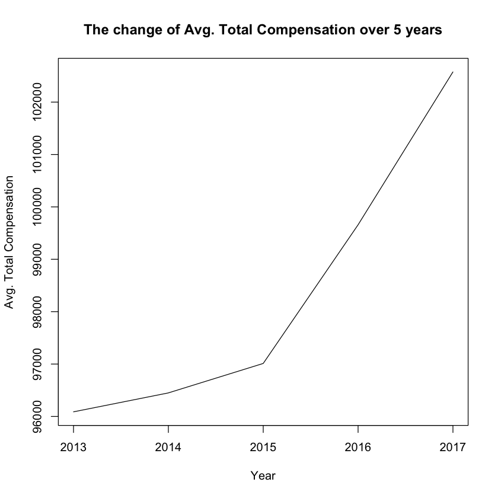

```r
# Total Compensation over 5 years
Total.Compensation_2013<-mean(dataset[dataset$Year=="2013",c("Total.Compensation")])
Total.Compensation_2014<-mean(dataset[dataset$Year=="2014",c("Total.Compensation")])
Total.Compensation_2015<-mean(dataset[dataset$Year=="2015",c("Total.Compensation")])
Total.Compensation_2016<-mean(dataset[dataset$Year=="2016",c("Total.Compensation")])
Total.Compensation_2017<-mean(dataset[dataset$Year=="2017",c("Total.Compensation")])
Total.Compensation<-c(Total.Compensation_2013,Total.Compensation_2014,Total.Compensation_2015,Total.Compensation_2016,Total.Compensation_2017)
year<-c(2013,2014,2015,2016,2017)

plot(year,Total.Compensation, type = "l", lty = 1,xlab = "Year", ylab = "Avg. Total Compensation",
   main = "The change of Avg. Total Compensation over 5 years")
```

The above line chart shows the variation of average total compensation data between 2013 to 2017.The average total compensation has faced a slight increment between 2013 to 2015. But it has shown a sharp rise in the average total compensation in 2016. Also, it has followed the trend in 2017 too. The overall trend was helpful for the employee. They have received more benefits from the employer.

# 4.3 Plots:

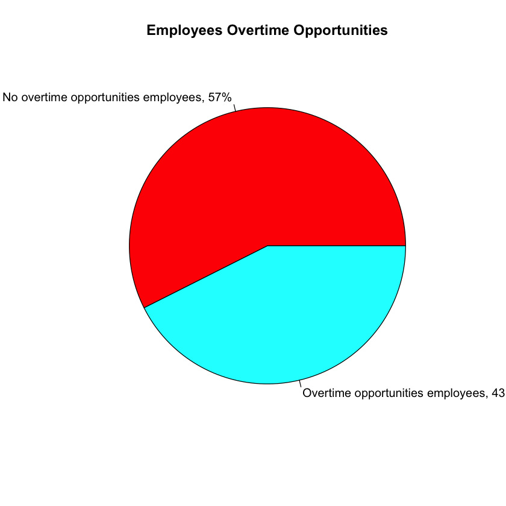

```r
overtime<-dataset[dataset$Overtime=="0",c("Overtime")]
No_overtime_opportunities_employees= length(overtime)/length(dataset$Overtime)
Overtime_opportunities_employees=1-No_overtime_opportunities_employees
slices <- c(No_overtime_opportunities_employees,Overtime_opportunities_employees)
lbls <- c("No overtime opportunities employees,", "Overtime opportunities employees,")
pct <- round(slices/sum(slices)*100)
lbls <- paste(lbls, pct) # add percents to labels
lbls <- paste(lbls,"%",sep="") # ad % to labels
pie(slices,labels = lbls, col=rainbow(length(lbls)),
   main="Employees Overtime Opportunities")
```

The above pie chart represents the percentage of the employee who has overtime opportunities. The overtime opportunity has brought the extra possibility to earn more wage. Those extra earnings have helped them to cope with the city's high living cost.

# 4.4 Plots:

```
Average:
```

9054.49969385841

```
Quantile:
```

**0%**

0

**25%**

4272.07

**50%**

12132.89

**75%**

12828.7075

**100%**

22270.12

```
 num [1:213202] 14920 12517 11309 13417 11989 ...
```

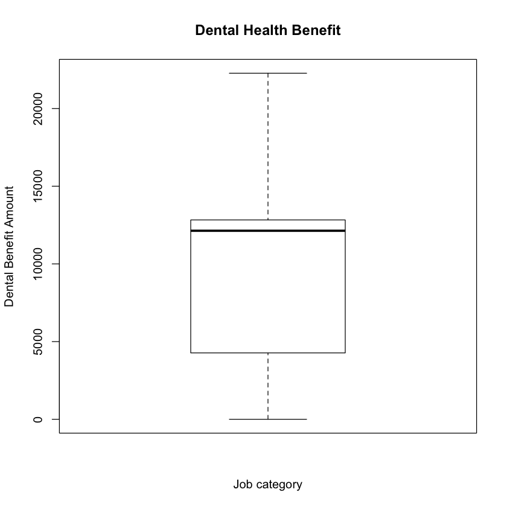

```r
#Health.Dental
Health.Dental<-dataset$Health.Dental
Health.Dental[Health.Dental<0]<-0
boxplot(Health.Dental,xlab = "Job category",ylab = "Dental Benefit Amount", main = "Dental Health Benefit")
cat("Average:")
mean(Health.Dental)
cat("\nQuantile:")
quantile(Health.Dental)
str(Health.Dental)
```

# 4.5 Plots:

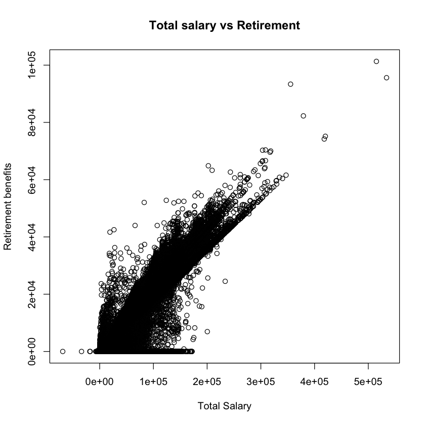

```r
Total.Salaries<-dataset$Total.Salaries
Total.Salaries[Total.Salaries<0]<-0

Retirement<-dataset$Retirement
Retirement[Retirement<0]<-0
plot(x = Salaries,y = Retirement,xlab = "Total Salary", ylab = "Retirement benefits",main = "Total salary vs Retirement"
)
```

# 5. Vectors:

```r
# Top earning job title in 2017
t_compensation<-dataset[dataset$Year=="2017" ,c("Job","Total.Compensation")] # dataset for 2017 all t_compensation
#head(sort(t_compensation$Total.Compensation,decreasing=TRUE),n=5)# print max
job_title<-c(t_compensation[t_compensation$Total.Compensation=="668412.41",c("Job")]
,t_compensation[t_compensation$Total.Compensation=="538791.72",c("Job")]
,t_compensation[t_compensation$Total.Compensation=="532690.64",c("Job")]
,t_compensation[t_compensation$Total.Compensation=="479167.2",c("Job")]
,t_compensation[t_compensation$Total.Compensation=="452385.2",c("Job")]
)
```

```r
job_title
```

1. 'Chief Investment Officer'

2. 'Physician Administrator, DPH'

3. 'Managing Director'

4. 'Transit Operator'

5. 'Dept Head V'

## 6. List

```r
#Total.Benefits	 list creation using total benefits : 2013 to 2017
# 2013
t_benefits_2013<-dataset[dataset$Year=="2013" ,c("Total.Benefits")]
avg_benefits_2013<-mean(t_benefits_2013)

#2014
t_benefits_2014<-dataset[dataset$Year=="2014" ,c("Total.Benefits")]
avg_benefits_2014<-mean(t_benefits_2014)
#2015
t_benefits_2015<-dataset[dataset$Year=="2015" ,c("Total.Benefits")]
avg_benefits_2015<-mean(t_benefits_2015)

#2016
t_benefits_2016<-dataset[dataset$Year=="2016" ,c("Total.Benefits")]
avg_benefits_2016<-mean(t_benefits_2016)
#2017

t_benefits_2017<-dataset[dataset$Year=="2017" ,c("Total.Benefits")]
avg_benefits_2017<-mean(t_benefits_2017)
# benefits list creation using the above calculated data

benefits_list_1<-list(Year="2013",avg_benefits=avg_benefits_2013)
benefits_list_2<-list(Year="2014",avg_benefits=avg_benefits_2014)
benefits_list_3<-list(Year="2015",avg_benefits=avg_benefits_2015)
benefits_list_4<-list(Year="2016",avg_benefits=avg_benefits_2016)
benefits_list_5<-list(Year="2017",avg_benefits=avg_benefits_2017)

# display: Five different list to store avg. benefits from 2013 to 2017
benefits_list_1
benefits_list_2
benefits_list_3
benefits_list_4
benefits_list_5
```

**$Year**

'2013'

**$avg_benefits**

25187.0854215219

**$Year**

'2014'

**$avg_benefits**

26395.0430481061

**$Year**

'2015'

**$avg_benefits**

27107.1200986582

**$Year**

'2016'

**$avg_benefits**

26250.3338966135

**$Year**

'2017'

**$avg_benefits**

26925.52979603

## 6.1 List Explaination

Total benefits column has been from the dataset. Using the different years of data, we have calculated the corresponding year average value to look into the employee total benefits status. The results are interesting in the way that from 2013 to 2015, employe total benefits have been increased even tough in a small amount. In 2016, it has dropped by -3.16% than 2015. Although the amount has risen by almost $700 in 2017. In summary, we can say that employees are not received enough benefits in comparison to their living cost.

# 7. Summery:

The analysis of dataset represents a good insight into SF Employee Compensation. The dataset is reliable ( by size, rows: 213202, columns: 22). Therefore, the chance to get an almost optimal solution for small projects is moderate. Employees salary ranges are wide. Skilled workers had higher earnings to semi-or non-skilled workers. Salary and total compensation are the two important columns in our dataset.

The income of the city's employee is standard. The average income (salary without benefits) from 2013 to 2017 was average 70,000 USD. Also, the median salary was $63k USD.  
Salary together with other facilities shows a healthy number. Using the different year's data, we have calculated the corresponding year total compensation average value to look into the employee total benefits status. The results are interesting in the way that from 2013 to 2015, employe total benefits have been increased even tough in a small amount. In summary, we can say that employees are not received enough benefits in comparison to their living cost.

# 8. Recommendations:

For the San Francisco Chronicle newspaper CEO, my recommendations are listed below: By analyzing the dataset, we have concluded that salary is directly related to employees spending power. If they earn good, they will spend more. Also, salary is closely associated with living cost. It is a common phenomenon that if the average salary is higher the living cost gets higher too. That is an almost common scenario in all major cities.